# Fitting Continuous Models Chapter 8

## This week in tgs data science

[Patient engagement tools for hernia surgeons](https://www.ahsqc.org/ahsqc-oracle)

https://statcomp2.app.vumc.org/ahsqc/predictions?age=21&female=1&race=American Indian or Alaskan Native&weight=120&height=66&recurrent=0&procedure_category=Incisional&indication_enlarged_hernia=0&indication_bowel_obstruction=0&indication_fistula=1&indication_infected_mesh=0&indication_pain=0&history_copd=0&history_immunosuppressants=0&history_open_abdomen=0&history_diabetes=0&history_dialysis=0&history_smoker=0&mesh_location=Onlay&details_myofascial_release=0&details_concomitant_procedure=0&details_stoma_present=0&hernia_width=20&asa_class=3&functional_status=Independent

## Where we are going

| Transformation | F Known Analytic | F Known Simulation | F Unknown Simulation (bootstrap) | F Unknown Kernel density | F Unknown Method of Moments | F Unknown MLE | F Unknown Bayes |
| --- | --- | --- | --- | --- | --- | --- | --- |
| None | N/A | N/A | N/A | Today | Next | Next | Soon |
| Mean | Soon | ✓ | ✓ | Soon | Soon | Soon | Soon |
| Median | ✓ | ✓ | ✓ | Soon | Soon | Soon | Soon |
| Variance | Soon | ✓ | ✓ | Soon | Soon | Soon | Soon |
| Min | ✓ | ✓ | Soon | Soon | Soon | Soon | Soon |
| Max | ✓ | ✓ | Soon | Soon | Soon | Soon | Soon |

## Key question

\[ \text{Suppose } X \sim F_X \text{ where } F_X \text{ is unknown.}\\ \text{How might one estimate } F_X \text{ from } \boldsymbol{X}_N ?\]

## Key question

\[ \text{Suppose } X \sim F_X \text{ where } F_X \text{ is unknown.}\\ \text{How might one estimate } F_X \text{ from } \boldsymbol{X}_N ?\]

### Example

```r
data <- c(
-1.26,  4.05,  0.37, -1.43,  3.33, -0.14,  4.81,  0.44,  1.62,
 4.75,  3.13,  4.56,  0.20,  5.00,  0.47, -0.48,  4.14,  3.62,
 0.70,  3.92,  0.84,  0.38, -0.87,  1.05, -3.69,  0.24,  1.47,
-5.37,  3.24, -6.76, -3.20,  3.84,  2.57,  0.05, -0.35, -2.77,
 5.84,  2.98,  1.06, -0.20,  6.82,  4.52, -1.31,  0.74, -1.86,
 0.17,  0.25,  1.19, -0.11, -0.22
)
```

## We already have one method

- The ECDF

```r
fhat <- ecdf(data)
plot(fhat, main = parse(text="ECDF~hat(F)[X]"))
```

## We already have one method

- The ECDF

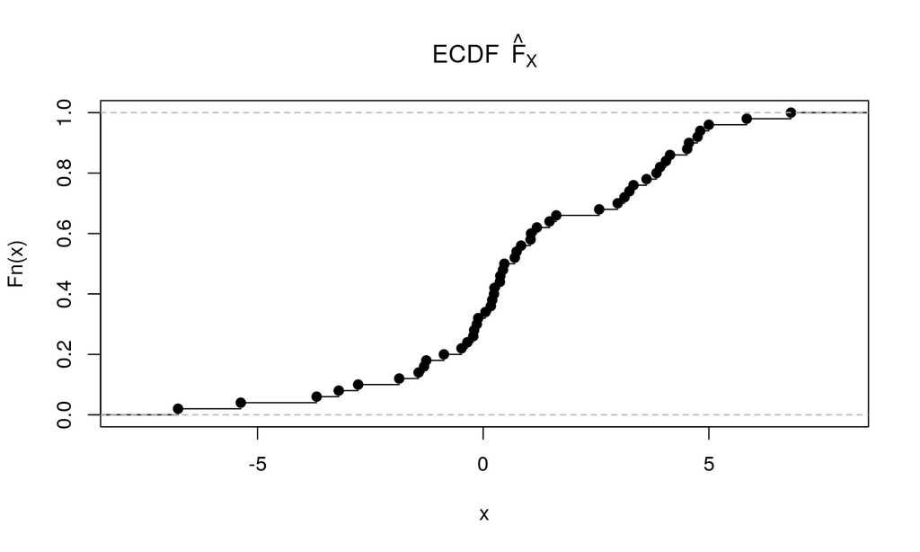

## Sidenote

Hats like \(\hat{\ }\) or \(\dot{\ }\) or \(\tilde{\ }\) are often used to denote an **estimate** of an expression.

For example \(\hat{\mu}\) or \(\dot{\sigma}\) or \(\tilde{F}\).

**Be careful:** The specific notation can change from document to document.

## Sidenote

Hats like \(\hat{\ }\) or \(\dot{\ }\) or \(\tilde{\ }\) are often used to denote an **estimate** of an expression.

For example \(\hat{\mu}\) or \(\dot{\sigma}\) or \(\tilde{F}\).

**Be careful:** The specific notation can change from document to document.

In this case, we might write the ECDF as \(\hat{F}_X\) to denote that it is an estimate of \(F_X\)

## Back to estimates of \(F_X\)

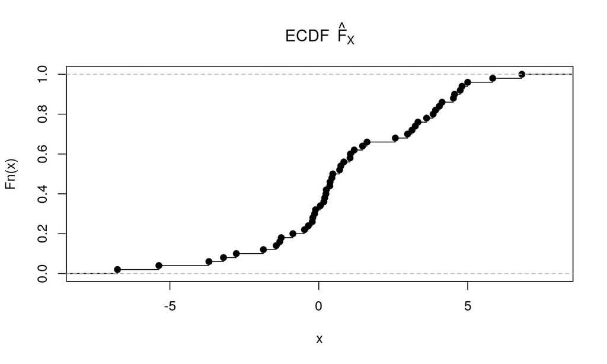

### What about an estimate of the PDF?

## The histogram

```r
h1 <- hist(data, main = "", xlab = "X")
```

## The histogram

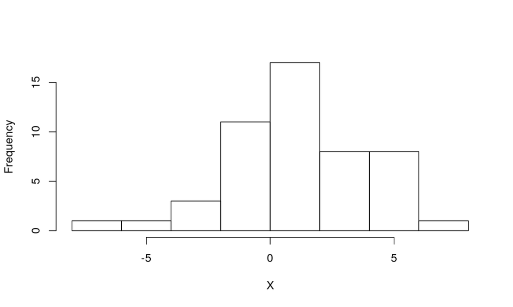

## The histogram

- Note that the number and size of the intervals is flexible

```r
par(mfrow = c(2,3), mar = c(0,0,0,0))
hist(data, axes = FALSE, main = "", breaks = c(-7, 0, 7))
hist(data, axes = FALSE, main = "", breaks = c(-7, -3, 0, 7))
hist(data, axes = FALSE, main = "", breaks = c(-7, -3, 0, 3, 7))
hist(data, axes = FALSE, main = "", breaks = 6)
hist(data, axes = FALSE, main = "", breaks = 12)
hist(data, axes = FALSE, main = "", breaks = 50)
```

## The histogram

- Note that the number and size of the intervals is flexible

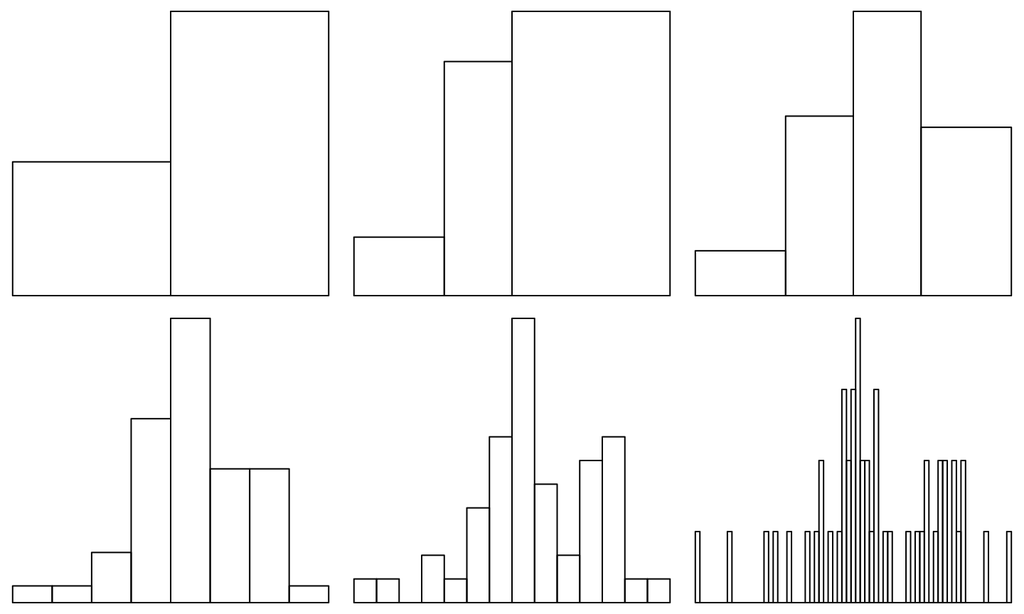

## The histogram

- The number and size of the intervals are related to the degree of **smoothness** in the resulting estimate.

### In data analysis, there is a **tension** between **degree of smoothness** and **generalizability**

- Too smooth \(\to\) cannot detect important population features
- Too rough \(\to\) capture artifacts of the sample that are not features of the population

## The histogram

- The number and size of the intervals are related to the degree of **smoothness** in the resulting estimate.

> > In data analysis, there is a **tension** between **degree of smoothness** and **generalizability**
- Too smooth \(\to\) cannot detect important population features **(ignorance)**
- Too rough \(\to\) capture artifacts of the sample that are not features of the population **(self deception)**

## The histogram

- The number and size of the intervals are related to the degree of **smoothness** in the resulting estimate.

> > In data analysis, there is a **tension** between **degree of smoothness** and **generalizability**
- Too smooth \(\to\) cannot detect important population features **(ignorance)**
- Too rough \(\to\) capture artifacts of the sample that are not features of the population **(self deception)**
- **Goldilocks** degree of smoothing \(\to\) detect important population features

## The histogram

- The number and size of the intervals are related to the degree of **smoothness** in the resulting estimate.

> > In data analysis, there is a **tension** between **degree of smoothness** and **generalizability**

The **tension** goes by many names:

- Bias variance tradeoff
- Under and over fitting

## The histogram

- The number and size of the intervals are related to the degree of **smoothness** in the resulting estimate.

> > In data analysis, there is a **tension** between **degree of smoothness** and **generalizability**

You will come across this tension in almost every data analysis method. The histogram happens to be the first method where most folks confront the issue.

## One step beyond the ECDF and histogram

Recall that the definition for the ECDF is

\[\text{ecdf}(t, \boldsymbol{X}_N) = \sum_{i = 1}^N \frac{1}{N}I(X_i \leq t)\]

## One step beyond the ECDF and histogram

Let’s take a deeper look at \(I(X_i \leq t)\).

```r
h <- function(t, Xi){
  1*(Xi <= t)
}
tgsify::plotstyle(style = upright, mfrow = c(1,1))
curve(h(x, 3), 2, 4, lwd = 3)
```

## One step beyond the ECDF and histogram

Let’s take a deeper look at \(I(X_i \leq t)\).

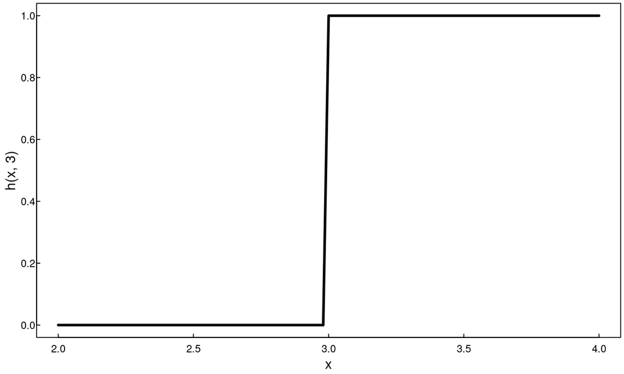

## One step beyond the ECDF and histogram

\(I(X_i \leq t)\) is a step function that jumps at \(X_i\).

\(\to\) All the mass is centered at \(X_i\)

## One step beyond the ECDF and histogram

\(I(X_i \leq t)\) is a step function that jumps at \(X_i\).

What if we wanted to spread the mass around to the values in a close neighborhood of \(X_i\)?

## One step beyond the ECDF and histogram

```r
k <- function(t, Xi) pnorm(t, Xi, sd = .1)
curve(h(x, 3), 2, 4, lwd = 3, ylab = "")
curve(k(x, 3), add = TRUE, col = "blue", lwd = 3)
```

## One step beyond the ECDF and histogram

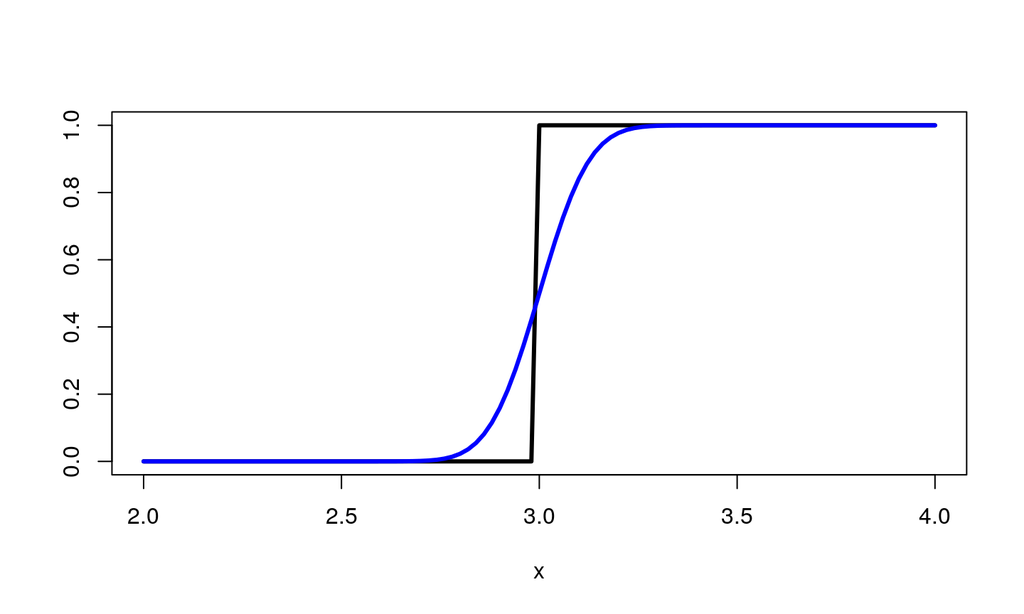

## One step beyond the ECDF and histogram

How would the ECDF change if we used

\[\text{pnorm}(t, X_i, .1) \text{ instead of } I(X_i \leq t)?\]

\[\text{ecdf*}(t, \boldsymbol{X}_N) = \sum_{i = 1}^N \frac{1}{N}\text{pnorm}(t, X_i, .1)\]

## One step beyond the ECDF and histogram

```r
ecdfstar <- function(t, data){
  outer(t, data, function(a,b){ pnorm(a, b, .1)}) %>% rowMeans
}
plot(ecdf(data), main = "")
curve(ecdfstar(x, data), add = TRUE, lwd = 3, col = "blue")
```

## One step beyond the ECDF and histogram

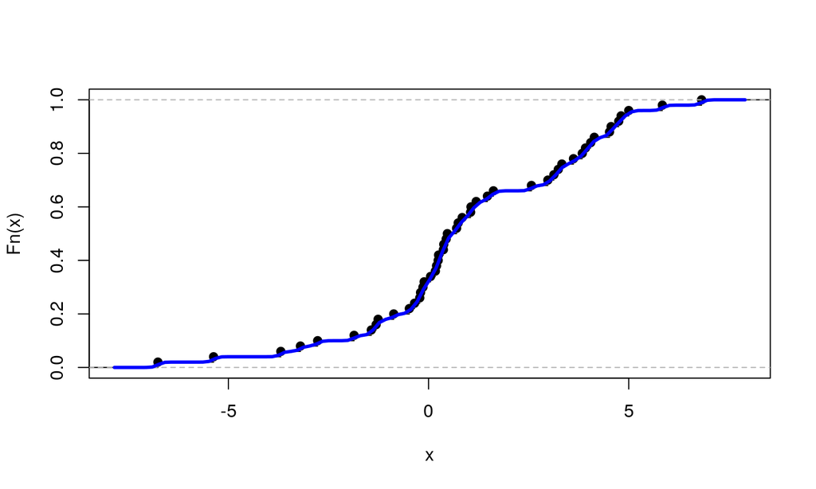

## One step beyond the ECDF and histogram

- Rather than a step function, we have a smooth function.
- How can we expand the function to control the degree of smoothing?

## One step beyond the ECDF and histogram

```r
ecdfstar <- function(t, data, smooth){
  outer(t, data, function(a,b){ pnorm(a, b, smooth)}) %>% rowMeans
}
plot(ecdf(data), main = "")
curve(ecdfstar(x, data, smooth = 1), add = TRUE, lwd = 3, col = "blue")
```

## One step beyond the ECDF and histogram

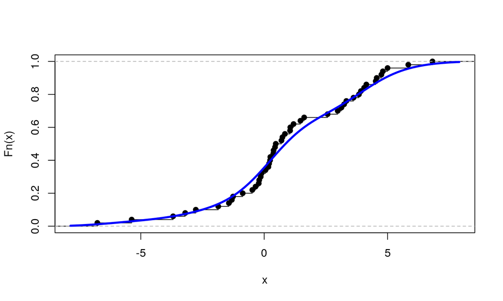

## One step beyond the ECDF and histogram

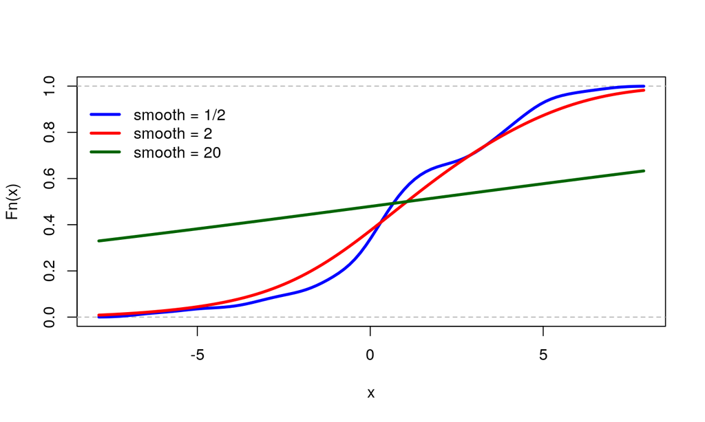

## One step beyond the ECDF and histogram

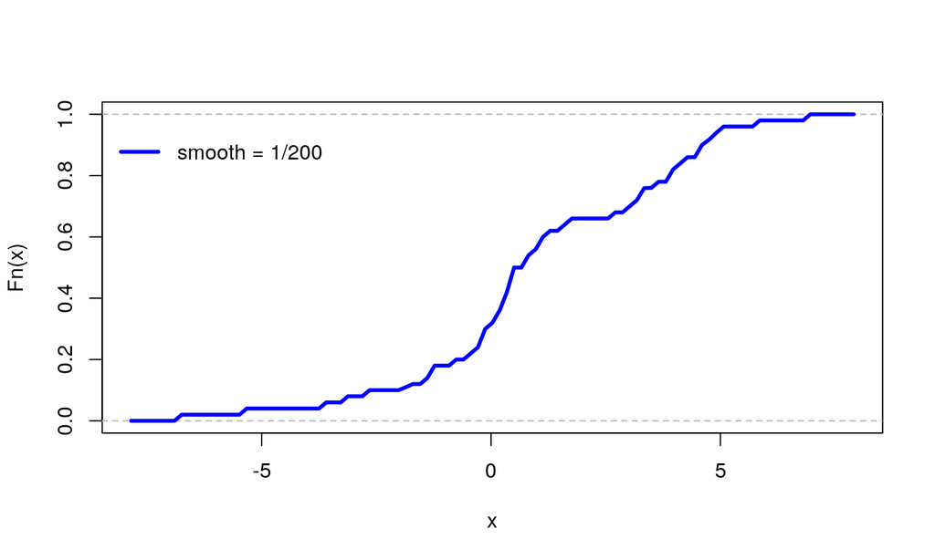

## Can also apply to EPDF

```r
epdfstar <- function(t, data, smooth){
  outer(t, data, function(a,b){ dnorm(a, b, smooth)}) %>% rowMeans
}
hist(data, freq = FALSE, main = "")
curve(epdfstar(x, data, smooth = 1), add = TRUE, lwd = 3, col = "blue")
```

## Can also apply to EPDF

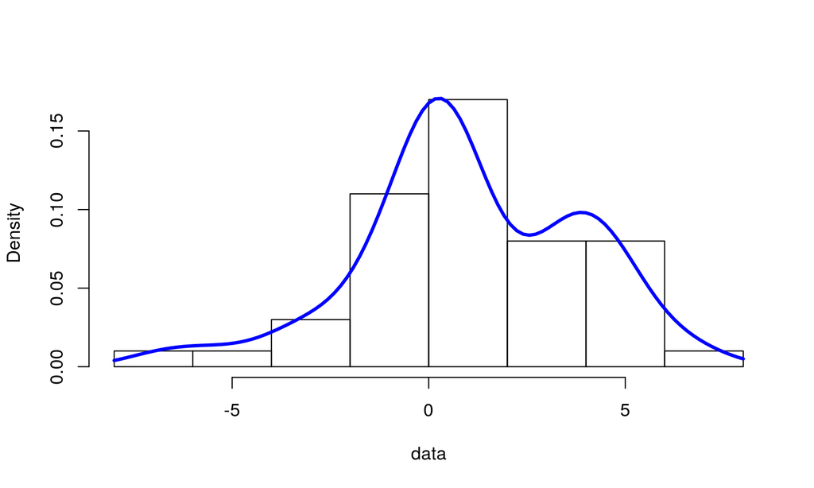

> > This method of estimating \(F_X\) and \(f_X\) is called **kernel density estimation**

## In R

The `density` function generates kernel density estimates.

```r
## Default S3 method:
density(
    x
  , bw = "nrd0"
  , adjust = 1
  , kernel = c("gaussian", "epanechnikov", "rectangular",
               "triangular", "biweight", "cosine", "optcosine")
  , ... MORE OPTIONS ...
)
```

## In R

The `density` function generates kernel density estimates.

```r
## Default S3 method:
density(
    x             # the data
  , bw = "nrd0"   # the degree of smoothing or a rule
  , adjust = 1    # the degree of smoothing relative to default
  , kernel =      # the type of kernel
  , ... MORE OPTIONS ...
)
```

## In R

Which kernel function did I use in the slides above?

```r
## Default S3 method:
density(
    x             # the data
  , bw = "nrd0"   # the degree of smoothing or a rule
  , adjust = 1    # the degree of smoothing relative to default
  , kernel =      # the type of kernel
  , ... MORE OPTIONS ...
)
```

## In R

Which kernel function did I use in the slides above? **gaussian**

```r
## Default S3 method:
density(
    x             # the data
  , bw = "nrd0"   # the degree of smoothing or a rule
  , adjust = 1    # the degree of smoothing relative to default
  , kernel =      # the type of kernel
  , ... MORE OPTIONS ...
)
```

## In R

Which kernel function did I use in the slides above? **gaussian**

What about the other kernels? See the text book and/or [here (link)](https://en.wikipedia.org/wiki/Kernel_%28statistics%29) for information on other kernels.

## In R

What about the other kernels? Here is a comparison with rectangular.

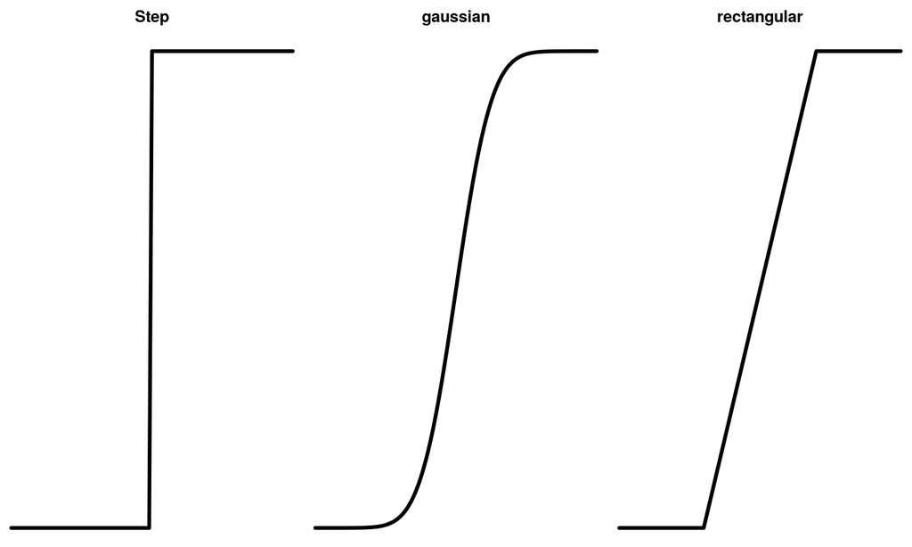

## Hands on

Generate a kernel density estimate of the gh in the nhgh data. Generate a plot that is very smooth, another that is very rough, and a third that you think has the right smoothness.

```r
Hmisc::getHdata(nhgh)
```